# MCMC Sampling for a Logistic Regression Model

## Packages

The following packages are used in this project:

- `here`: enables easy file referencing and builds file paths in a OS-independent way
- `stats`: loads this before loading `tidyverse` to avoid masking some `tidyverse` functions
- `cumstats`: efficiently computing cumulative standard deviation
- `tidyverse`: includes collections of useful packages like `dplyr` (data manipulation), `tidyr` (tidying data), `ggplots` (creating graphs), etc.
- `skimr`: provide summary statistics about variables in data frames, tibbles, data tables and vectors
- `glue`: embedding and evaluating R expressions into string to be printed as message
- `scales`: formats and labels scales nicely for better visualization
- `broom`: tidy and unify the fit objects returned by most of the modeling functions
- `TeachingDemos`: empirical HPD intervals

In addition, the `pacman` package provides handy tools to manage R packages (install, update, load and unload). We use its `p_laod()` instead of `libarary()` to load the packages listed above.

```r
# packages
if (!require("pacman")) utils::install.packages("pacman", dependencies = TRUE)
pacman::p_load(
    here,
    stats, cumstats,
    tidyverse,
    skimr, glue, scales, gt,
    broom,
    TeachingDemos
)

# helper function: string concatenation (ex: "act" %&% "5")
'%&%' <- function(x, y) paste0(x, y)

# not %in%
'%notin%' <- Negate('%in%')
```

In this work, we reuse one of the helper function we developed before `dist_summary`. It conveniently gives graphical (histogram) and numeric summaries (mean, median, standard deviation and confidence intervals) of a distribution from a vector. In this updated version, we add the credible intervals by using `TeachingDemos::CI_hpd()`.

> Arguments:
> - `x`: A numeric vector
> - `var_expression`: expression used in plot axis label
> - `pos_x`, `pos_y`, `adj`: position of text annotation on the plot
> - `conf.level`: confidence level
> - `digits`: number of decimal places
> - `plot`: include plot or not

> Returned Value: A data frame with numeric summaries

```r
# summarize a distribution (graphically and numerically)
dist_summary <- function(
    x, var_expression,
    pos_x = 0, pos_y = 1, adj = c(0, 1),
    conf.level = 0.95, digits = 4, plot = T, ...){

  # significance level
  alpha <- (1 - conf.level)/2

  # mean, median, and intervals
  mean <- mean(x)
  median <- median(x)
  sd <- sd(x)
  CI <- quantile(x, probs = c(alpha, 1 - alpha)) %>% `names<-`(vec_fmt_percent(c(alpha, 1 - alpha), decimals = 1))
  CI_hpd <- TeachingDemos::emp.hpd(x) %>% `names<-`(vec_fmt_percent(c(alpha, 1 - alpha), decimals = 1))

  if(plot){
    # plot distributions with annotations of mean, median and CIs
    hist_obj <- hist(
      x,
      probability = T,
      col = NULL,
      yaxt = "n",
      xlab = var_expression,
      main = "Histogram")

    # add lines
    abline(v = mean, col = "red", lwd = 2)
    abline(v = median, col = "blue", lwd = 2)
    abline(v = CI)
    abline(v = CI_hpd, lty = 2, col = "green")

    # annotation
    text(
      quantile(hist_obj$breaks, probs = pos_x),
      quantile(hist_obj$density, probs = pos_y),
      glue(
        "Mean = {signif(mean, digits)}\n",
        "Median = {signif(median, digits)}\n",
        "Std = {signif(sd, digits)}\n",
        "{conf.level*100}% credible interval:\n",
        "  Equal-tail = ({toString(signif(CI, digits))})\n",
        "  HPD = ({toString(signif(CI_hpd, digits))})\n"
      ),
      adj = adj, ...)
  }

  # return summaries
  return(tibble(
    mean = mean,
    median = median,
    sd = sd,
    CI = list(CI),
    CI_hpd = list(CI_hpd)
  ))
}
```

## Data

Load the data and have a quick look at it to check its summary, data type and completeness:

```r
diabetes <- read_csv("diabetes-dataset.csv", show_col_types = F)

# skim the data
skim(diabetes)
```

Data summary

| Name | diabetes |
| --- | --- |
| Number of rows | 2000 |
| Number of columns | 9 |
| _______________________ |  |
| Column type frequency: |  |
| numeric | 9 |
| ________________________ |  |
| Group variables | None |

**Variable type: numeric**

| skim_variable | n_missing | complete_rate | mean | sd | p0 | p25 | p50 | p75 | p100 | hist |
| --- | --- | --- | --- | --- | --- | --- | --- | --- | --- | --- |
| Pregnancies | 0 | 1 | 3.70 | 3.31 | 0.00 | 1.00 | 3.00 | 6.00 | 17.00 | ▇▃▂▁▁ |
| Glucose | 0 | 1 | 121.18 | 32.07 | 0.00 | 99.00 | 117.00 | 141.00 | 199.00 | ▁▁▇▆▂ |
| BloodPressure | 0 | 1 | 69.15 | 19.19 | 0.00 | 63.50 | 72.00 | 80.00 | 122.00 | ▁▁▇▇▁ |
| SkinThickness | 0 | 1 | 20.93 | 16.10 | 0.00 | 0.00 | 23.00 | 32.00 | 110.00 | ▇▇▁▁▁ |
| Insulin | 0 | 1 | 80.25 | 111.18 | 0.00 | 0.00 | 40.00 | 130.00 | 744.00 | ▇▂▁▁▁ |
| BMI | 0 | 1 | 32.19 | 8.15 | 0.00 | 27.37 | 32.30 | 36.80 | 80.60 | ▁▇▇▁▁ |
| DiabetesPedigreeFunction | 0 | 1 | 0.47 | 0.32 | 0.08 | 0.24 | 0.38 | 0.62 | 2.42 | ▇▃▁▁▁ |
| Age | 0 | 1 | 33.09 | 11.79 | 21.00 | 24.00 | 29.00 | 40.00 | 81.00 | ▇▃▁▁▁ |
| Outcome | 0 | 1 | 0.34 | 0.47 | 0.00 | 0.00 | 0.00 | 1.00 | 1.00 | ▇▁▁▁▅ |

There is no missing values in any column. The response variable `Outcome` is numeric and has two possible values.

```r
# count table for the response variable
table(diabetes$Outcome)
```

```
##
##    0    1
## 1316  684
```

## MCMC MH Algorithm and Implementation

In this work, we are interested to model the response `Outcome` by `Glucose` with a logistic linear regression model:

$$Y=\log\frac{P(success)}{1-P(success)}=\beta_0+\beta_1
X$$

The likelihood (data) is a product of binomial pdf and the prior distributions for the parameters $\beta_0$ and $\beta_1$ are chosen to be two independent normal distributions $\sim N(0, 15^2)$:

$$\begin{aligned}
L &= f_{\underset{\sim}{\beta_0},
\underset{\sim}{\beta_1}|\mathbf{Y}}(\beta_0,\beta_1|\mathbf{y}) \\
&\propto f_{\mathbf{Y}|\underset{\sim}{\beta_0},
\underset{\sim}{\beta_1}}(\mathbf{y}|\beta_0,\beta_1) \cdot
f_\underset{\sim}{\beta_0}(\beta_0) f_\underset{\sim}{\beta_1}(\beta_1)
\\
&\propto \prod_{i=1}^n \left[ p(x_i)^{y_i} \cdot \left(1-p(x_i)
\right)^{1-y_i} \right] \times
\left[ \sigma_0^2 \cdot e^{ (\beta_0-\beta_{00})^2/\sigma_0^2 }
\right]^{-1/2} \times
\left[ \sigma_1^2 \cdot e^{ (\beta_1-\beta_{10})^2/\sigma_1^2 }
\right]^{-1/2} \\
l &= \ln L \\
&= \sum_{i=1}^n \left[ y_i\ln p(x_i) + (1-y_i)\ln \left(1 -
p(x_i)\right) \right]
-\frac{1}{2} \left(\ln \sigma_0^2 +
\frac{(\beta_0-\beta_{00})^2}{\sigma_0^2} \right)
-\frac{1}{2} \left(\ln \sigma_1^2 +
\frac{(\beta_1-\beta_{10})^2}{\sigma_1^2} \right) + \text{constant}
\end{aligned}$$

Based on the equations above, we therefore define the following helper functions to calculate the terms needed in MCMC MH algorithm:

- `expit()`: calculate the expit $p(x_i|\beta_0,\beta_1)$
- `logprior()`: log prior for $\beta_0 \sim N(0, 15^2)$ or $\beta_1 \sim N(0, 15^2)$
- `logpost()`: log posterior (the last equation showed above)

```r
# calculate p
expit <- function(X, beta0, beta1) {
  return( 1/(1 + exp(-beta0 - beta1*X)) )
}

# log prior for beta
logprior <- function(beta, mean = 0, sd = 15) {
  return( -0.5*(log(sd^2) + (beta - mean)^2/sd^2) )
}

# log posterior
logpost <- function(Y, X, beta0, beta1){
  P <- expit(X, beta0, beta1)
  return( sum(Y*log(P) + (1-Y)*log(1-P)) + logprior(beta0) + logprior(beta1) )
}
```

Next we define a sampler function to carry out Markov Chain Monte Carlo (MCMC) Metropolis-Hastings algorithm in a **univariate** manner (search one parameter at a time). To compare the performance, we also keep track of the process time `proc_time` and if a proposed candidate is accepted `accept`. In each iteration:

- if both candidates are accepted, `accept = 1` (100% acceptance)
- if only one is accepted, `accept = 0.5` (50% acceptance)
- if none is accepted, `accept = 0`

> Arguments:
> - `Y`, `X`: response and prediction variables
> - `N`: number of MCMC iteration
> - `beta0_init` and `beta0_init`: initial values of the parameters
> - `pos_x`, `pos_y`, `adj`: position of text annotation on the plot
> - `proposed_sd0` and `proposed_sd1`: standard deviation of jumping distribution for parameter candidates
> - `seed`: seed for random number generator

> Returned Value: A data frame with all sampled values of the parameters, process time and acceptance indicator

```r
# MCMC MH sampler - univariate manner
mcmc_mh <- function(
    Y, X, N = 1000 * 10,
    beta0_init = 0, proposed_sd0 = 0.01,
    beta1_init = 0, proposed_sd1 = 0.01,
    seed = 2022){

  # make the simulation reproducible
  if(!is.null(seed)) set.seed(seed)

  # start timer
  proc_timer <- proc.time()

  # set up a data frame to store beta0 and beta1
  df <-  tibble(
    beta0 = beta0_init,
    beta1 = beta1_init,
    proc_time = (proc.time() - proc_timer)["elapsed"],
    accept = 0
  )

  # current step - initialize
  beta0 <- beta0_init
  beta1 <- beta1_init

  # log posterior for the current step
  l <- logpost(Y, X, beta0, beta1)

  # iteration
  for (i in 2:N) {
    # reset accept score
    accept <- 0

    # beta0: pick a candidate
    beta0_new <- rnorm(1, beta0, proposed_sd0)
    # new log posterior
    l_new <- logpost(Y, X, beta0_new, beta1)
    # decide whether to accept or reject
    lnR <- l_new - l
    lnU <- log(runif(1))
    if(lnR > lnU){
      beta0 <- beta0_new
      l <- l_new
      accept <- accept + 0.5
    }

    # beta1: pick a candidate
    beta1_new <- rnorm(1, beta1, proposed_sd1)
    # new log posterior
    l_new <- logpost(Y, X, beta0, beta1_new)
    lnR <- l_new - l
    lnU <- log(runif(1))
    if(lnR > lnU){
      beta1 <- beta1_new
      l <- l_new
      accept <- accept + 0.5
    }

    # save betas and elapsed time
    df <- df %>% add_row(
      beta0 = beta0,
      beta1 = beta1,
      proc_time = (proc.time() - proc_timer)["elapsed"],
      accept = accept
    )
  }

  print(glue(
    "Last values: (beta0, beta1) = ({beta0}, {beta1})\n",
    "Process time [s]: {tail(df$proc_time, 1)}\n",
    "Acceptance rate: {mean(df$accept)}"
  ))

  # return all betas
  return(df)
}
```

The following helper function is to summarized sampled values returned by MCMC sampler function. It creates several plots to show how algorithm is executed (steps, process time and acceptance rate) as well as a summary report on obtained beta values (posterior mean, median and credible intervals):

> Arguments:
> - `df`: a data frame with all sampled values
> - `burn_in`: number of burn_in iteration to remove

> Returned Value: A data frame with posterior mean, median and credible intervals

```r
mcmc_summary <- function(df, burn_in, ...){
  # add cumulative mean of acceptance (acceptance rate)
  df <- mutate(df, cum_accept_rate = cummean(accept))

  N <- nrow(df)
  proc_time <- tail(df$proc_time, 1)
  acceptance_rate <- tail(df$cum_accept_rate, 1)

  # plot algorithm performance
  par(mfrow = c(1,3))
  # plot 1: trace
  plot(df$beta0, df$beta1, type = "l", xlab = expression(beta[0]), ylab = expression(beta[1]))
  text(df$beta0[1], df$beta1[1], "Start", col = "blue")
  text(tail(df$beta0, 1), tail(df$beta1, 1), "End", col = "red")
  # plot 2: process time
  plot(df$proc_time, type = "l", xlab = "Iteration", ylab = "Process Time [s]")
  text(N/2, proc_time, round(proc_time, 2) %&% " [s]", col = "red")
  # plot 3: acceptance rate
  plot(df$cum_accept_rate, type = "l", xlab = "Iteration", ylab = "Acceptance Rate")
  text(N*0.9, acceptance_rate, vec_fmt_percent(acceptance_rate, 2), col = "red")

  # remove burn-in rows
  df2 <- tail(df, - burn_in)

  # plot distributions of betas with annotations of mean, median and CIs
  par(mfrow = c(1,2))
  beta0 <- dist_summary(df2$beta0, var_expression = expression(beta[0]), ...)
  beta1 <- dist_summary(df2$beta1, var_expression = expression(beta[1]), ...)

  # reset par options
  par(mfrow = c(1,1))

  # combine betas and report intervals, process time and acceptance rate
  bind_rows(list(beta0 = beta0, beta1 = beta1), .id = "term") %>%
    # unpack list columns for intervals
    unnest_wider(c(CI, CI_hpd), names_sep = "_") %>%
    mutate(
      proc_time = proc_time,
      acceptance_rate = acceptance_rate
    )
}
```

## Simulation and Results

```r
# simulation setup
N <- 1000 * 100
burn_in <- N/10
```

We use the sampler function `mcmc_mh()` to perform MCMC MH with $(0,0)$ as starting values and (0.01, 0.001) as proposed standard deviation of the jumping distribution for $(\beta_0, \beta_1)$ respectively. After plotting the algorithm steps, process time and accumulative acceptance rate, we call `mcmc_summary()` to remove the burn-in rows and plot histograms and summarize the posterior mean, median and credible intervals:

```r
# MCMC MH  - univariate manner
df_univar <- mcmc_mh(
  Y = diabetes$Outcome, X = diabetes$Glucose, N = N,
  beta0_init = 0, proposed_sd0 = 0.01,
  beta1_init = 0, proposed_sd1 = 0.001) %>%
  mcmc_summary(burn_in)
```

```
## Last values: (beta0, beta1) = (-5.52522334113172, 0.0390173084051903)
## Process time [s]: 169.22
## Acceptance rate: 0.68779
```

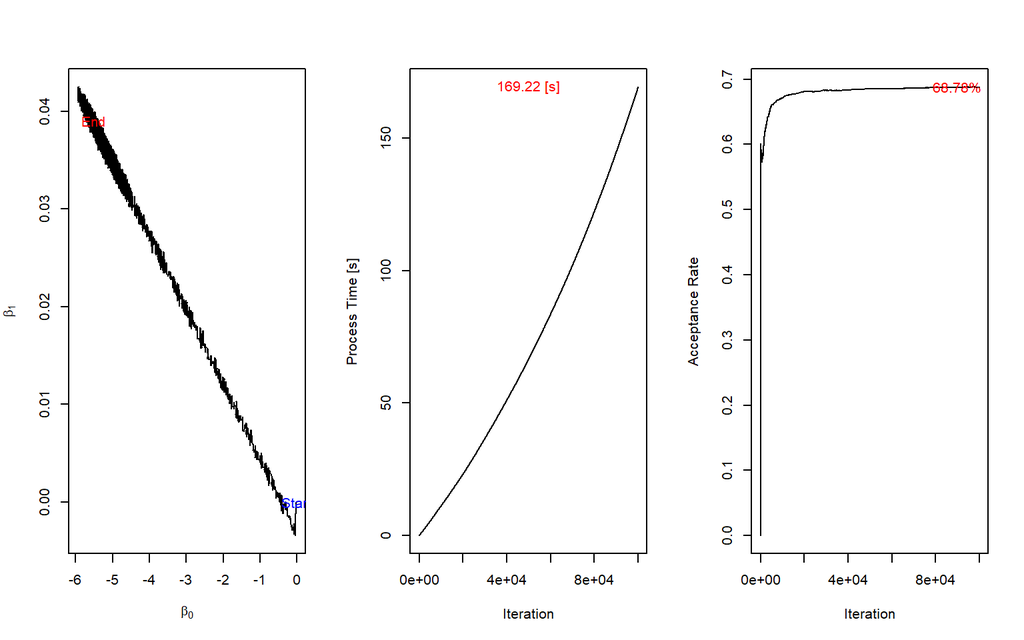

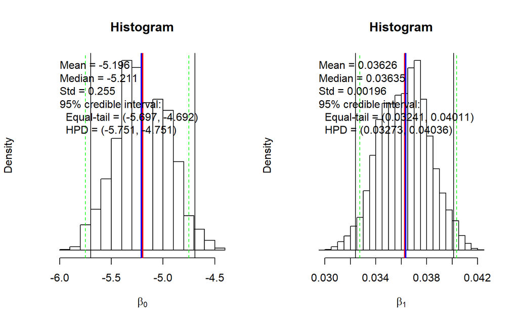

```r
df_univar
```

| term | mean | median | sd | CI_2.5% | CI_97.5% | CI_hpd_2.5% | CI_hpd_97.5% | proc_time | acceptance_rate |
| --- | --- | --- | --- | --- | --- | --- | --- | --- | --- |
| beta0 | -5.19608010 | -5.21081154 | 0.254969140 | -5.69724600 | -4.69211109 | -5.75058703 | -4.75059605 | 169.22 | 0.68779 |
| beta1 | 0.03625927 | 0.03634556 | 0.001960118 | 0.03240641 | 0.04010558 | 0.03273384 | 0.04035683 | 169.22 | 0.68779 |

MCMC takes 169.22 seconds to complete 10^{5} iteration in univariate manner. On average, the acceptance rate of candidates drawn from the jumping distributions is 0.68779.

## GLM - MLE fit

To get an idea about how good our obtained results, we use `glm()` to fit the logistic regression model (maximum likelihood method):

```r
# fit a GLM logistic regression model
proc_timer <- proc.time()
fit <- glm(Outcome ~ Glucose, family = binomial(link = 'logit'), data = diabetes)
proc_time <- proc.time() - proc_timer

# summary
summary(fit)
```

```
##
## Call:
## glm(formula = Outcome ~ Glucose, family = binomial(link = "logit"),
##     data = diabetes)
##
## Coefficients:
##              Estimate Std. Error z value Pr(>|z|)
## (Intercept) -5.254362   0.257281  -20.42   <2e-16 ***
## Glucose      0.036696   0.001973   18.60   <2e-16 ***
## ---
## Signif. codes:  0 '***' 0.001 '**' 0.01 '*' 0.05 '.' 0.1 ' ' 1
##
## (Dispersion parameter for binomial family taken to be 1)
##
##     Null deviance: 2569.4  on 1999  degrees of freedom
## Residual deviance: 2108.1  on 1998  degrees of freedom
## AIC: 2112.1
##
## Number of Fisher Scoring iterations: 4
```

```r
# estimate, SE and 95% CI
df_glm <- tidy(fit, conf.int = T) %>%
  mutate(proc_time = proc_time["elapsed"])

df_glm
```

| term | estimate | std.error | statistic | p.value | conf.low | conf.high | proc_time |
| --- | --- | --- | --- | --- | --- | --- | --- |
| (Intercept) | -5.25436192 | 0.257280657 | -20.42269 | 1.051237e-92 | -5.76761651 | -4.75867254 | 0.02 |
| Glucose | 0.03669568 | 0.001972784 | 18.60097 | 3.155756e-77 | 0.03289289 | 0.04062958 | 0.02 |

The estimates are close to what we obtained using MCMC-MH. Both methods have similar standard deviations and CIs on the parameters. The major difference is the computation time: MCMC takes much longer to execute.

## Additional Study - MCMC MH Bivariate Manner

With the assumption of the independence of the two parameters $\beta_0$ and $\beta_1$, we can perform the sampling process in bivariate manner:

```r
# MCMC MH sampler - bivariate manner
mcmc_mh2 <- function(
    Y, X, N = 1000 * 10,
    beta0_init = 0, proposed_sd0 = 0.01,
    beta1_init = 0, proposed_sd1 = 0.01,
    seed = 2022){

  # make the simulation reproducible
  if(!is.null(seed)) set.seed(seed)

  # start timer
  proc_timer <- proc.time()

  # set up a data frame to store beta0 and beta1
  df <-  tibble(
    beta0 = beta0_init,
    beta1 = beta1_init,
    proc_time = (proc.time() - proc_timer)["elapsed"],
    accept = 0
  )

  # current step - initialize
  beta0 <- beta0_init
  beta1 <- beta1_init

  # log posterior for the current step
  l <- logpost(Y, X, beta0, beta1)

  # iteration
  for (i in 2:N) {
    # reset accept score
    accept <- 0

    # pick candidates
    beta0_new <- rnorm(1, beta0, proposed_sd0)
    beta1_new <- rnorm(1, beta1, proposed_sd1)
    # candidate's log posterior
    l_new <- logpost(Y, X, beta0_new, beta1_new)
    # decide whether to accept or reject
    lnR <- l_new - l
    lnU <- log(runif(1))
    if(lnR > lnU){
      beta0 <- beta0_new
      beta1 <- beta1_new
      l <- l_new
      accept <- 1
    }

    # save betas and elapsed time
    df <- df %>% add_row(
      beta0 = beta0,
      beta1 = beta1,
      proc_time = (proc.time() - proc_timer)["elapsed"],
      accept = accept
    )
  }

  print(glue(
    "Last values: (beta0, beta1) = ({beta0}, {beta1})\n",
    "Process time [s]: {tail(df$proc_time, 1)}\n",
    "Acceptance rate: {mean(df$accept)}"
  ))

  # return all betas
  return(df)
}
```

For a fair comparison, we use the same setup to execute the sampler function `mcmc_mh2()`:

```r
# MCMC MH - bivariate manner
df_bivar <- mcmc_mh2(
  Y = diabetes$Outcome, X = diabetes$Glucose, N = N,
  beta0_init = 0, proposed_sd0 = 0.01,
  beta1_init = 0, proposed_sd1 = 0.001) %>%
  mcmc_summary(burn_in)
```

```
## Last values: (beta0, beta1) = (-4.95027052778182, 0.0346536657845713)
## Process time [s]: 146.84
## Acceptance rate: 0.43319
```

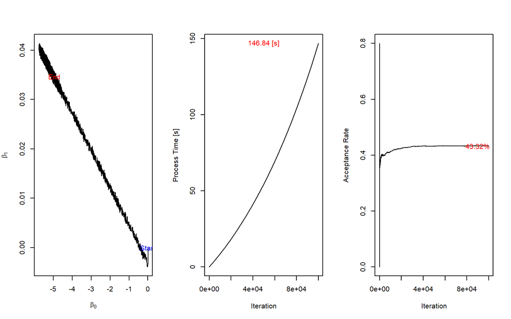

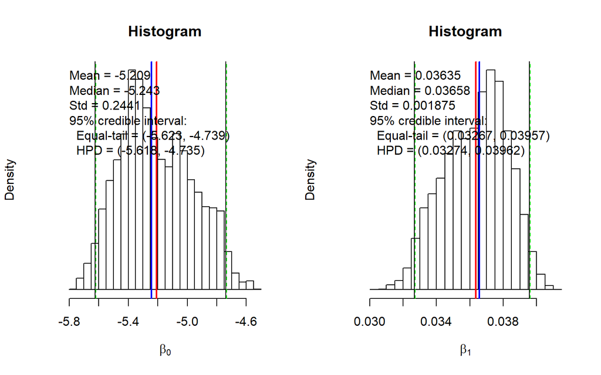

```r
df_bivar
```

| term | mean | median | sd | CI_2.5% | CI_97.5% | CI_hpd_2.5% | CI_hpd_97.5% | proc_time | acceptance_rate |
| --- | --- | --- | --- | --- | --- | --- | --- | --- | --- |
| beta0 | -5.20865518 | -5.24267841 | 0.244107244 | -5.62348944 | -4.73868090 | -5.61816491 | -4.73486578 | 146.84 | 0.43319 |
| beta1 | 0.03635475 | 0.03657665 | 0.001874828 | 0.03267056 | 0.03957097 | 0.03273599 | 0.03962204 | 146.84 | 0.43319 |

MCMC takes 146.84 seconds to complete 10^{5} iteration in bivariate manner. On average, the acceptance rate of candidates drawn from the jumping distributions is 0.43319, which is lower than the univariate counterpart. This is likely due to the fact that we propose two new candidates for both parameters simultaneously and this has higher chance to enter rejection zone.

```r
# A naive way to compare efficiency of process time usage
glue(
  "Process Time Wasted [s] := Process Time * (1 - Acceptance Rate)\n",
  "MCMC-MH univariate: {round(df_univar$proc_time[1] * (1 - df_univar$acceptance_rate[1]), 2)} [s]\n",
  "MCMC-MH bivariate:  {round(df_bivar$proc_time[1] * (1 - df_bivar$acceptance_rate[1]), 2)} [s]"
)
```

```
## Process Time Wasted [s] := Process Time * (1 - Acceptance Rate)
## MCMC-MH univariate: 52.83 [s]
## MCMC-MH bivariate:  83.23 [s]
```

Beside this downside, the results are slightly better in term of smaller standard deviation and narrower CI.

## Comparison and Conclusion

To compare all three methods:

```r
# combine all results for comparison
bind_rows(
  # from glm
  df_glm %>%
    rename(
      "sd" = "std.error",
      `CI_2.5%` = conf.low,
      `CI_97.5%` = conf.high) %>%
    mutate(
      term = if_else(term == "(Intercept)", "beta0", "beta1"),
      method = "MLE"
    ),
  # from MCMC: univariate and bivariate
  df_univar %>% mutate(method = "MCMC_MH_univar"),
  df_bivar %>% mutate(method = "MCMC_MH_bivar")
  ) %>%
  # calculate width of intervals
  mutate(CI_width = `CI_97.5%` - `CI_2.5%`) %>%
  # select columns of interest
  select(term, method, estimate, median, sd, `CI_2.5%`, `CI_97.5%`, CI_width, proc_time, acceptance_rate) %>%
  # make it easy to read
  mutate(across(where(is.numeric), ~ round(.x, 4))) %>%
  arrange(term)
```

| term | method | estimate | median | sd | CI_2.5% | CI_97.5% | CI_width | proc_time | acceptance_rate |
| --- | --- | --- | --- | --- | --- | --- | --- | --- | --- |
| beta0 | MLE | -5.2544 | NA | 0.2573 | -5.7676 | -4.7587 | 1.0089 | 0.02 | NA |
| beta0 | MCMC_MH_univar | NA | -5.2108 | 0.2550 | -5.6972 | -4.6921 | 1.0051 | 169.22 | 0.6878 |
| beta0 | MCMC_MH_bivar | NA | -5.2427 | 0.2441 | -5.6235 | -4.7387 | 0.8848 | 146.84 | 0.4332 |
| beta1 | MLE | 0.0367 | NA | 0.0020 | 0.0329 | 0.0406 | 0.0077 | 0.02 | NA |
| beta1 | MCMC_MH_univar | NA | 0.0363 | 0.0020 | 0.0324 | 0.0401 | 0.0077 | 169.22 | 0.6878 |
| beta1 | MCMC_MH_bivar | NA | 0.0366 | 0.0019 | 0.0327 | 0.0396 | 0.0069 | 146.84 | 0.4332 |

All three methods have similar values for parameters. Although MCMC-MH bivariate method is faster and slightly better (in term of sd and CI) than MCMC-MH univariate method, it is still much slower than MLE fit (maximum likelihood method).